# Linear and non-linear regression

## Today’s goals

Explore

- the mathematical formula,
- implementation, and
- interpretation

of linear and non-linear regression models applied for optimum-finding in agriculture.

## Regression

Statistical method for fitting a line to data where the relationship between two variables, a quantitative outcome ($Y$) and a quantitative predictor ($X$), are of interest.

## Regression

The quantitative predictor of the regression model can take different forms, including:

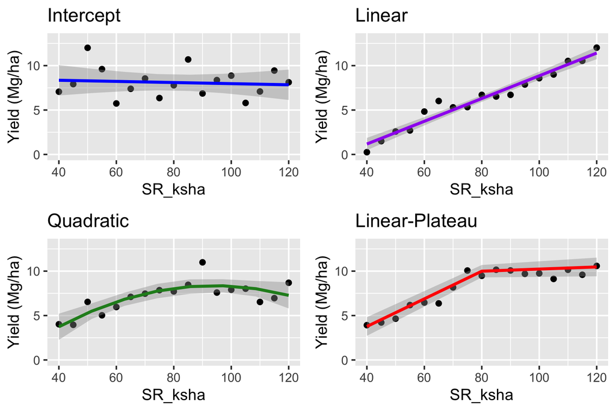

Let’s explore each of them next.

# Model 1 - Intercept

## Model 1 - Intercept

The **intercept-only** model only contains one fixed-effect parameter:

$$\Large{Y = \color{blue}{b_0} + \epsilon}$$

intercept, $b_0$ (aka overall mean of the response variable)

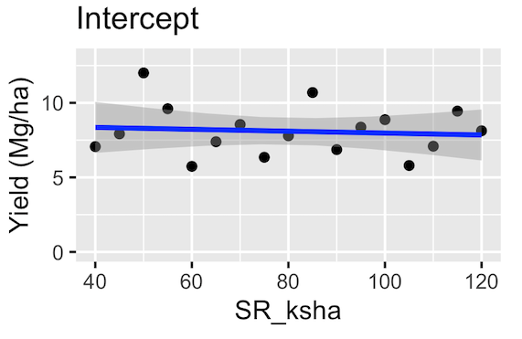

## Model 1 - Intercept

```
# A tibble: 1 × 3
  term        estimate p.value
  <chr>          <dbl>   <dbl>
1 (Intercept)     12.2  0.0002
```

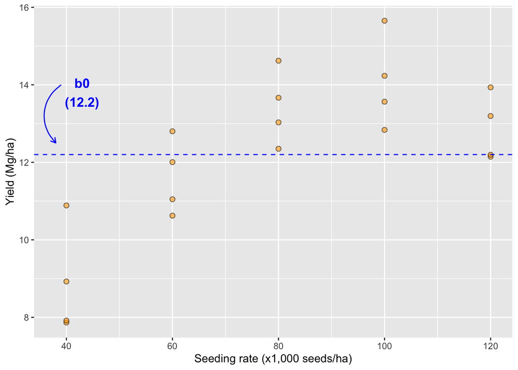

Yield is 12.2 Mg/ha regardless of seeding rate.

# Model 2 - Linear

## Model 2 - Linear

The **linear (intercept + slope)** model contains two fixed-effect parameters:

$$\Large{Y = \color{blue}{b_0} + \color{purple}{b_1} X + \epsilon}$$

- intercept, $b_0$ (where line cuts the y-axis when x = 0)
- slope, $b_1$ (change in y for each unit change on x)

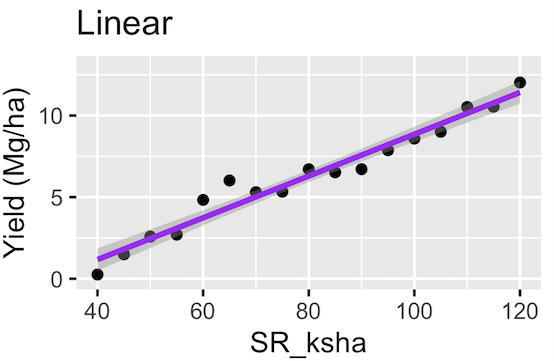

## Model 2 - Linear

```
# A tibble: 2 × 3
  term        estimate p.value
  <chr>          <dbl>   <dbl>
1 (Intercept)   8.02    0
2 sr_ksha       0.0520  0.0001
```

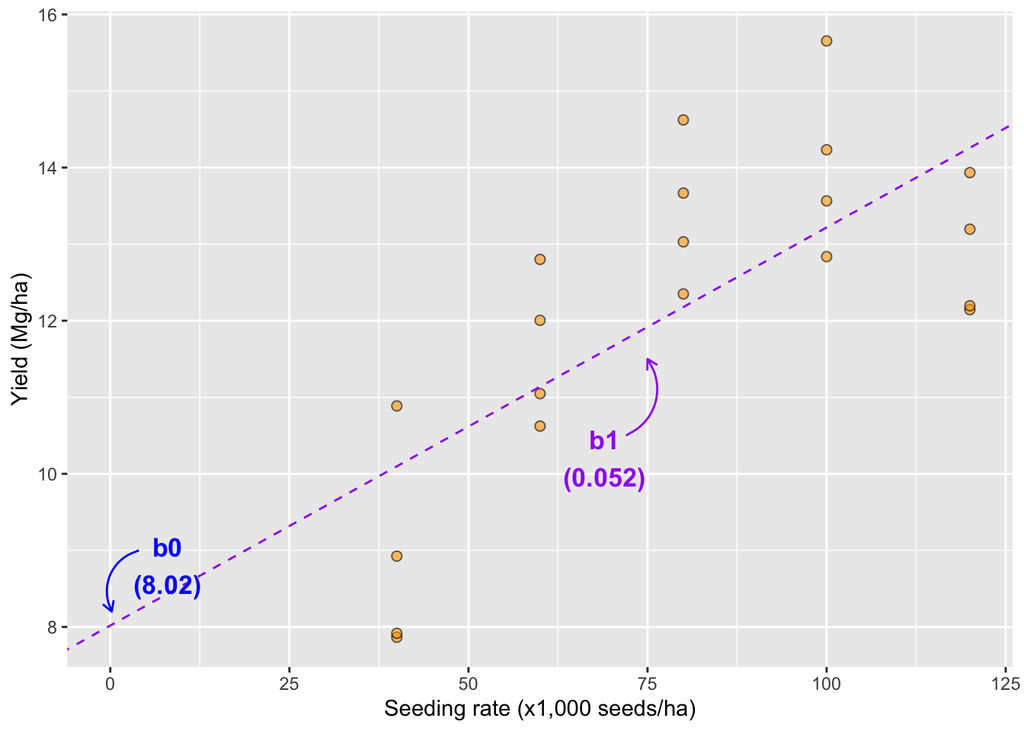

For each **1-unit increase** in seeding rate, yield increases **0.052 Mg/ha**.

# Model 3 - Quadratic

## Model 3 - Quadratic

The **quadratic** model contains three fixed-effect parameters:

$$\Large{Y = \color{blue}{b_0} + \color{purple}{b_1} X + \color{forestgreen}{b_2} X^2 +\epsilon}$$

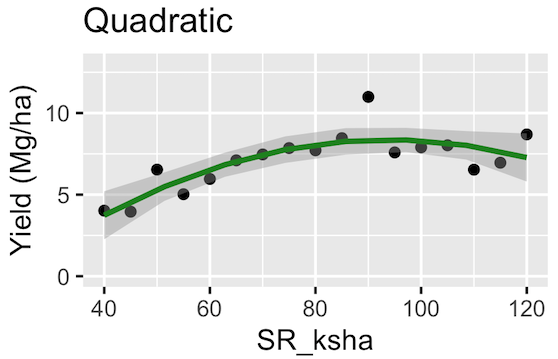

## Model 3 - Quadratic

```
# A tibble: 3 × 3
  term         estimate p.value
  <chr>           <dbl>   <dbl>
1 (Intercept)  -0.976     0.275
2 sr_ksha       0.309     0
3 I(sr_ksha^2) -0.00161   0
```

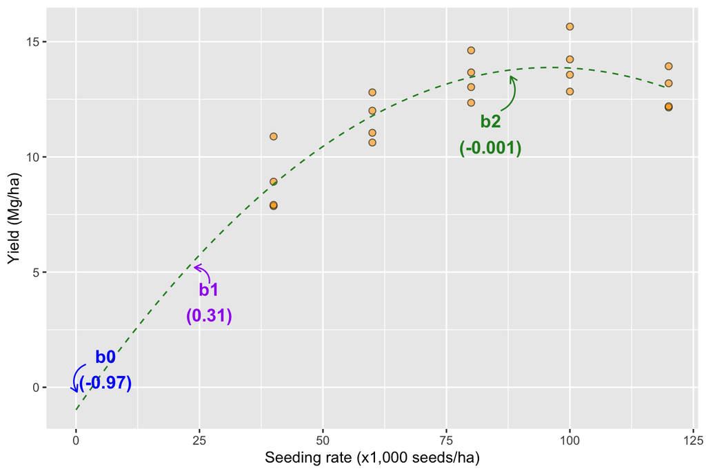

# Model 4 - Linear-plateau

## Model 4 - Linear-plateau

The **linear-plateau** model contains three fixed-effect parameters:

$$\begin{cases}
x < \color{red}{xs},\ Y = \color{blue}{b_0} + \color{purple}{b_1} X \\
x > \color{red}{xs},\ Y = \color{blue}{b_0} + \color{purple}{b_1} \color{red}{xs}
\end{cases}$$

- intercept, $b_0$ (where line cuts the y-axis when x = 0)
- slope, $b_1$ (change in y for each unit change on x until xs)
- break-point, $xs$ (x axis value where y is optimized)

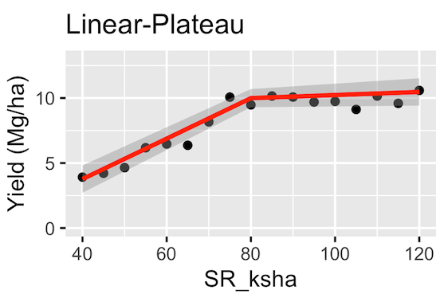

## Model 4 - Linear-plateau

```
# A tibble: 3 × 3
  term  estimate p.value
  <chr>    <dbl>   <dbl>
1 a        3.46   0.0075
2 b        0.136  0
3 xs      73.5    0
```

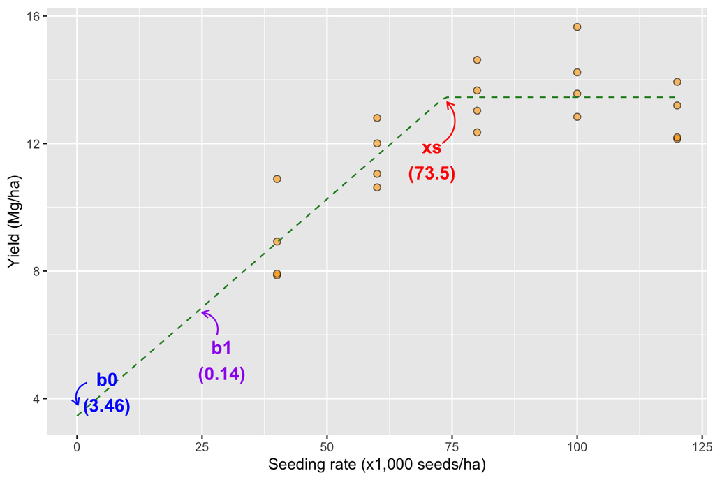

Yield **increases linearly** as seeding rate increases (b1 > 0) **until a threshold (xs = 73.5 k seeds/ha)**, after which point yield remains constant.

## Summary

We covered the mathematical formula, implementation, and interpretation of the different regression models, including linear and non-linear.